# Rcpp读书笔记：第一章Rcpp简介

## 1.1 背景：从R到C++

R语言是从S语言进化来的，R和S语言近三十年来一直在进化。举例说明，R语言通过S3和S4类系统实现面向对象特性，也包括新的参考类(reference class)。这种进化，有时候让新手看起来更加复杂（perplexing），也会让中高级开发者感觉语言特性的不连续。巧合的是（Coincidentally），C++也存在同样的问题。

这些争论听起来有些道理，但实际上不是那么回事。人们更加关心语言的可用性。一个语言的关键特性是，可以**再现**整个数据分析过程。

下边是一个例子,数据来自美国黄石公园老忠实喷泉（Old Faithful Geyser）的喷发和等待时间。喷发时间的密度函数曲线见下图。

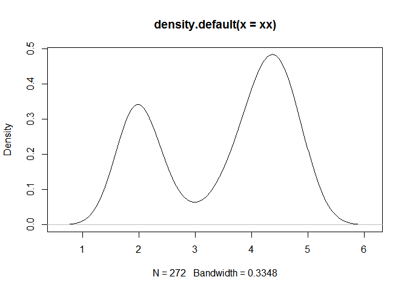

图1 老忠实泉喷发时间密度曲线

```r
xx <- faithful$eruptions
fit <- density(xx)
plot(fit)
```

语言完美的展示了R的面向对象特性，利用plot函数，可以直接对函数density的返回结果**fit**进行图形绘制。

接下来展示的代码，说实话没怎么看懂。

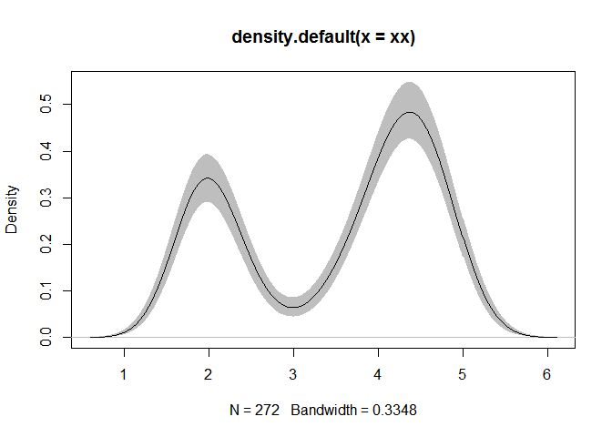

图2 Bootstrap 置信区间

```r
xx <- faithful$eruptions
fit1 <- density(xx)
fit2 <- replicate(10000,
                  {
                    x <- sample(xx, replace = TRUE)
                    density(x, from = min(fit1$x), to = max(fit1$x))$y
                  })
fit3 <- apply(fit2, 1, quantile, c(0.025, 0.975))
plot(fit1, ylim = range(fit3))
polygon(c(fit1$x, rev(fit1$x)),
        c(fit3[1, ], rev(fit3[2, ])),
        col = 'grey',
        border = F)
lines(fit1)
```

3-6行执行一个最小型的bootstrap抽样。replicate函数对第二个参数重复了10000次。 第二个参数是一个代码段，包含了2个命令。

```r
x <- sample(xx,replace=TRUE);
```

第一个命令，主要是进行重复抽样，构建一个新的数据集，主要是次序不一样。 第二个命令密度函数。其他就看不下去了，应该要看一下bootstrap的原理才会明白。

R内部执行的关键是它的核心解释器，扩展机制通过C语言执行。C语言的关键特性是可扩展性，通过外部库和外部模块完成。Rcpp的主要优势是，可以替代C，快速的写R的扩展。

## 1.2 第一个例子

斐波那契（Fibonacci）数列，就是一个递归序列，从第三个数开始，是前两个数的和。公式为：
$$F_{n}=F_{n-1}+F_{n-2}$$

### 1.2.1 Fibonacci的R版本

计算函数可以定义为：

```r
fibR <- function(n) {
  if(n==0) return(0)
  if(n==1) return(1)
  return(fibR(n-1)+fibR(n-2))
}
```

上述函数并没有进行优化，没有对输入值进行判断，也不是特别有效率。譬如输入5，那么会计算fibR(4)和fibR(3)，但是等到fibR(4)的时候，会计算fibR(3)和fibR(2),fibR(3)被计算了2次。

### 1.2.3 Fibonacci的C++版本

令人惊喜的是，可以在Rcmd中调用Rcpp执行C++代码。通过在chunk头中定义`engine="Rcpp"`或者直接用`{Rcpp}`表示。

```cpp
#include <Rcpp.h>
using namespace Rcpp;

// [[Rcpp::export]]
int fibC(const int x) {
    if (x == 0 || x == 1) return(x);
    return (fibC(x - 1)) + fibC(x - 2);
}
```

上述代码是在R中调用C++代码的一种形式。还有另外一种形式，说实话，没怎么看懂。 对比一下这两个函数的性能，主要是通过**microbenchmark**包来进行。

```r
library(microbenchmark)
microbenchmark(
  fibR(20),
  fibC(20)
)
```

```
## Unit: microseconds
##      expr      min       lq       mean   median        uq       max neval
##  fibR(20) 7653.270 8063.111 8508.27239 8296.576 8788.5955 14321.299   100
##  fibC(20)   18.629   19.231   32.69459   23.587   28.9955   835.007   100
##  cld
##    b
##   a
```

### 1.2.4 Fibonacii的原始调用C++版本

难以理解的调用C++的一个写法，用到了Rcpp的两个关键函数*as*和*wrap*.其中as的作用是把SEXP类型的xs变量转换为 C++需要的int类型。SEXP是S expression type的缩写，int是integer的缩写。相反，wrap的作用是把int类型的fib变量转换为R需要的SEXP类型。

```cpp
int fibonacci(const int x) {
  if (x == 0) return(0);
  if (x == 1) return(1);
  return (fibonacci(x - 1)) + fibonacci(x - 2);
}

extern "C" SEXP fibWrapper(SEXP xs) {
  int x = Rcpp::as<int>(xs);
  int fib = fibonacci(x);
  return (Rcpp::wrap(fib));
}
```

接下来的工作，是要把这两个函数进行编译、链接成一个共享库（shared library)，目的是为了让R可以载入。这三步，事实上每一步都非常复杂，而且耗时费力。引入**inline**包，来简化完成这项工作。

### 1.2.5 Fibonacii的可理解和可执行版本

```r
incltxt <- '
int fibonacci(const int x) {
  if (x==0) return(0);
  if (x==1) return(1);
  return fibonacci(x-1)+fibonacci(x-2);
}'

fibRcpp <- inline::cxxfunction(signature(XS="int"),
                       plugin = "Rcpp",
                       incl=incltxt,
                       body='
int x=Rcpp::as<int>(XS);
return Rcpp::wrap(fibonacci(x));
')
```

上面的代码，事实上主要是提供了两个参数：

- 第一个参数**incltxt**包括纯C++代码；
- 第二个参数是包括在函数cxxfunction内的body内容，主要是对接口的定义；
- cxxfunction的主要目的，是对C++函数进行包装，定义为可以在R内运行；
  - XS定义为在R中运行时的输入参数,通过函数signature进一步定义和包装;
  - plugin 选择Rcpp来进行接口转换?不确定;
  - incl是C++函数体;
  - body定义如何转换;

一旦完成上述定义，我们来比较一下三种函数的运行速度,fibR,fibC,fibRcpp。从下边的结果来看，fibC和fibRcpp优势非常明显。

```r
microbenchmark(fibR(20),
               fibC(20),
               fibRcpp(20))
```

```
## Unit: microseconds
##         expr      min        lq       mean   median        uq       max
##     fibR(20) 7862.097 8345.2525 9419.28216 9261.535 10232.654 13403.063
##     fibC(20)   18.930   21.7845   27.58067   25.541    32.001    50.480
##  fibRcpp(20)   30.047   33.0525   37.58322   36.808    39.813    96.751
##  neval cld
##    100   b
##    100  a
##    100  a
```

### 1.2.6 fibonacii第二种解法R版本

这种写法，用到local函数,实际上是local中的代码进行评估，但是local提供一种环境，这些代码中变量仅在这个环境中有效。 计算fibonacii时，对每个数字的fibonacii值存储，下次用的时候直接调用。

```r
mfibR <- local({
  memo <- c(1,1,rep(NA,1000))
  f <- function(x){
    if (x == 0) return(0)
    if (x<0) return(NA)
    if (x > length(memo))
      stop("x too big for implementation")
    if (!is.na(memo[x])) return(memo[x])
    ans <- f(x-1) + f(x-2)
    memo[x] <- ans
    ans
  }
})
```

### 1.2.7 fibonacii第二种写法C++版本

通过1.2.5 的方法，定义如下:

```r
mincltxt <- '
#include <algorithm> //具体的用途？
#include <vector>
#include <stdexcept>
#include <cmath>
#include <iostream>

class Fib {
public:
  Fib(unsigned int n = 1000){
    memo.resize(n);  //设置数组为1000个元素
    std::fill(memo.begin(),memo.end(),NAN); //设置数组memo为空值
    memo[0] = 0.0;
    memo[1] = 1.0;
  }
  double fibonacci (int x) {
    if (x < 0)
      return((double) NAN);
    if (x >= (int) memo.size())
      throw std::range_error(\"x too large for implementation\");
    if (! std::isnan(memo[x]))
      return(memo[x]);
    memo[x] = fibonacci(x-2) + fibonacci(x-1);
    return(memo[x]);
  }
private:
  std::vector <double> memo;
};
'


mfibRcpp <- inline::cxxfunction(signature(xs="int"),
                                plugin = "Rcpp",
                                includes = mincltxt,
                                body = '
int x = Rcpp::as<int>(xs);
Fib f;
return Rcpp::wrap(f.fibonacci(x-1));
')
```

第一次接触C++**类的概念**，类Fib包括三个元素

- constructor 构建器或称构建函数，初始化前调用，主要用途是对数组memo进行赋值
- 一个公开的成员函数，用来实现Fibonacci计算
- 一个私有向量memo

貌似必须遵循先公开有私有的顺序？一些特别需要注意的地方：

- 类的定义最后一个大括号后边要加;
- 私有向量，类型的定义，类型要用<>表示。
- 而在代码中，(int) memo.size() 又是用括号表示？

对定义的c++类，在R中进行包装和输出。

比较一下mfibR和mfibRcpp两种方法的效率。

```r
microbenchmark(mfibR(20),mfibRcpp(20))
```

```
## Unit: nanoseconds
##          expr      min         lq        mean   median       uq       max
##     mfibR(20) 42551050 44732011.5 49213445.29 46749817 50606799 145317777
##  mfibRcpp(20)      902     1352.5     8062.07     1954    13822     55888
##  neval cld
##    100   b
##    100  a
```

### 1.2.8 第三种方法（迭代法)

```r
fibRiter <- function(n) {
  first = 0
  second = 1
  third = 0
  for (i in seq_len(n)) {
    third = first + second
    first = second
    second = third
  }
  return(first)
}
fibRcppiter <- inline::cxxfunction(signature(xs='init'),
                                   plugin = "Rcpp",
                                   body = '
int n = Rcpp::as<int>(xs);
double first = 0;
double second = 1;
double third = 0;
for (int i=0; i<n; i++) {
    third = first + second;
    first = second;
    second = third;
}
return Rcpp::wrap(first);
')
```

三种方法运行时间的比较：C++代码，迭代法运行时间一次降低。令人惊奇的是，对于R代码，第二种方法的运行时间最长。可能与local函数有关系，第一种方法加载后，第二次不用重新运行？

```r
microbenchmark(fibR(20),
               fibC(20),
               mfibR(20),
               mfibRcpp(20),
               fibRiter(20),
               fibRcppiter(20)
)
```

```
## Unit: nanoseconds
##             expr      min         lq        mean     median         uq
##         fibR(20)  7660181  7884481.5  9248122.50  8507505.5 10380485.5
##         fibC(20)    18930    22385.5    29022.83    29747.0    32902.0
##        mfibR(20) 42371068 46717366.5 51640929.91 50121691.0 54893754.0
##     mfibRcpp(20)      902     1503.0     8019.90     9314.5    12470.0
##     fibRiter(20)     1202     2254.0    35320.80     6010.0     7662.5
##  fibRcppiter(20)        0     1353.0     5135.50     4807.0     7212.0
##       max neval cld
##  14227552   100  b
##     48376   100 a
##  76234331   100   c
##     25240   100 a
##   2983967   100 a
##     51982   100 a
```

## 1.3 第二个例子

关于两个变量1阶自回归(autogressive process of order one for two variables)的描述,公式符号为$VAR(1)$，表述为：
$$X_{t}=AX_{t-1}+u_{t}$$
现在考虑更为一般的形式，p阶$VAR(p)$表述为:
$$X_{t}=A_{1}X_{t-1}+A_{2}X_{t-2}+...+A_{p}X_{t-p}+u_{t}$$

### 1.3.1 R代码

```r
#定义系数矩阵A和残差矩阵u
a <- matrix(c(0.5,0.1,0.1,0.5),nrow = 2)
u <- matrix(rnorm(10000),ncol=2)
rSim <- function(coeff,errors){
  simdata <- matrix(0,nrow(errors),ncol(errors))
  for (row in 2:nrow(errors)) {
    simdata[row,] = coeff %*% simdata[(row-1),]+errors[row,]
  }
  return(simdata)
}
rData <- rSim(a,u)
```

上述代码中，需要说明的是`coeff`是2×2矩阵，而`sima[(row-1),]`为包括2个元素的向量，二者相乘的结果相当于`2×2 %*% 2×1`，结果为`2×1`矩阵。errors[row,]为包括2个元素的向量，跟前边结果相加，相当于`2×1 + 2×1`。结果是一个`2×1`矩阵，但是竟然可以作为一个向量赋值给simdata[row,]。

### 1.3.2 C++代码

本次C++代码用到了另外一个包RcppArmadillo,这个包主要是一个基础的线性代数运算包，包括稠密和稀疏矩阵的四则运算，求逆矩阵等。在本次代码中，主要是用来定义矩阵，以及相关的运算。C++中，矩阵读取的下标是()而不是[]。

```r
suppressMessages(require(inline))
code <- '
  arma::mat coeff = Rcpp::as<arma::mat>(a);
  arma::mat errors = Rcpp::as<arma::mat>(u);
  int m = errors.n_rows;
  int n = errors.n_cols;
  arma::mat simdata(m,n);
  simdata.row(0) = arma::zeros<arma::mat>(1,n);
  for (int row=1; row<m; row++) {
    simdata.row(row) = simdata.row(row-1)*trans(coeff)+errors.row(row);

  }
  return Rcpp::wrap(simdata);
'

##创建编译函数
rcppSim <- cxxfunction(signature(a="numeric",u="numeric"),
                       body=code,
                       plugin="RcppArmadillo")
rcppData <- rcppSim(a,u)
stopifnot(all.equal(rData, rcppData))
```

对于`simdata.row(0) = arma::zeros<arma::mat>(1,n);`不是很理解。

### 1.3.3 性能比较

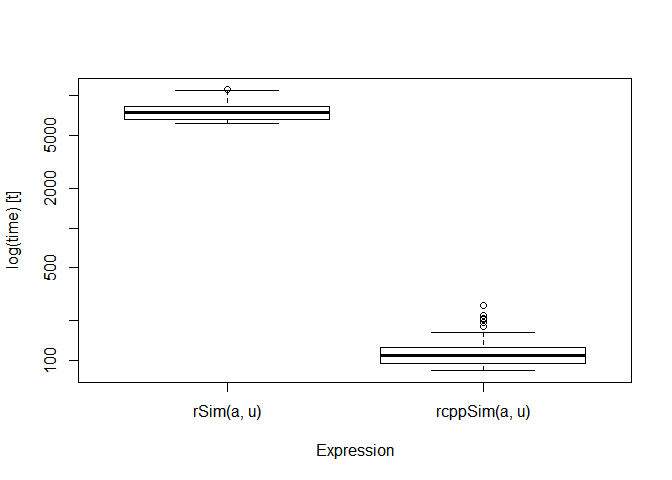

```r
boxplot(microbenchmark::microbenchmark(rSim(a,u),rcppSim(a,u)))
```